# K Means Clustering

Will Doyle

# Introduction

K means clustering is an example of *unsupervised learning*, a set of techniques used to identify patterns of association within a dataset that are not driven by the analyst. This technique is employed when it is strongly suspected that there are latent classifications of individuals in a dataset, but those classifications are unknown.

There are many types of unsupervised learning—this is a very active area of development in data science. K-means is among the simplest, and is relatively easy to explain. It’s also pretty good— it tends to get decent answers. K-means proceeds by finding some number (K) groups of observations that are quite similar to one another, but quite different from other groups of observations. Similarity in this case is defined as having minimum variation within the group. The way this is done in practice is to start by randomly assigning each observation to a cluster, then to calculate the cluster centroid, which is the means of the variables used for the algorithm. Next, assign each observation to the cluster centroid which is closest to its means. This continues until no more changes are possible. If the data have clear underlying partitions, then the cluster assignment will be pretty stable. If not, then each time you run this algorithm, you could get different answers. There are solutions to this problem we’ll go over, but please remember this basic fact about K-means clustering, which is different than any of the algorithms we cover in this class:

*K MEANS CLUSTERING IN ITS BASIC FORM CAN GIVE YOU DIFFERENT ANSWERS EACH TIME YOUR RUN IT*.

In our example today, we’re going to take survey data from a group of passengers who were going through San Francisco international airport over the course of a week. The goal is to identify groups of passengers. Once we’ve identified these groups, we’ll use group membership to predict a couple of outcomes: whether or not the passenger had a problem, and whether or not the passenger said they had an outstanding experience.

```r
rm(list = ls())
library(tidyverse)
library(stats)
library(flexclust)
```

```r
library(ggplot2)
library(LICORS)
library(knitr)
library(modelr)
```

The SFO survey data is pretty standard survey data, the kind you might get back from surveymonkey or qualtrics or other similar survey software.

First, I load the dataset containing individual characteristics. We’ll load the dependent variables later.

```r
load("sf_cluster.RData")
sfo <- sf_cluster %>% select(-sf.runid)
```

# Determining the Number of Clusters

The first step in running cluster analysis is to figure out how many clusters are needed. It’s generally assumed that there are at least 3 clusters, but it’s not easy to think about how many more might be needed.

The `stepFlexClust` command can be helpful here. What it will do is to run a cluster analysis a certain number of times for a certain number of clusters, choosing the best fit (minimum distance) from each set of runs for each number of clusters. We can then take a look at the distances generated and plot them.

```r
# Test to see how many clusters are needed
c_test <- stepFlexclust(sfo, k = 2:7, nrep = 20)
```

```
## 2 : * * * * * * * * * * * * * * * * * * * *
## 3 : * * * * * * * * * * * * * * * * * * * *
## 4 : * * * * * * * * * * * * * * * * * * * *
## 5 : * * * * * * * * * * * * * * * * * * * *
## 6 : * * * * * * * * * * * * * * * * * * * *
## 7 : * * * * * * * * * * * * * * * * * * * *
```

```r
c_test
```

```
## stepFlexclust object of family 'kmeans'
##
## call:
## stepFlexclust(x = sfo, k = 2:7, nrep = 20)
##
##   iter converged  distsum
## 1   NA        NA 7152.029
## 2   23      TRUE 6642.461
## 3   12      TRUE 6381.596
## 4   20      TRUE 6205.597
## 5   22      TRUE 6032.783
## 6    9      TRUE 5887.118
## 7   10      TRUE 5765.523
```

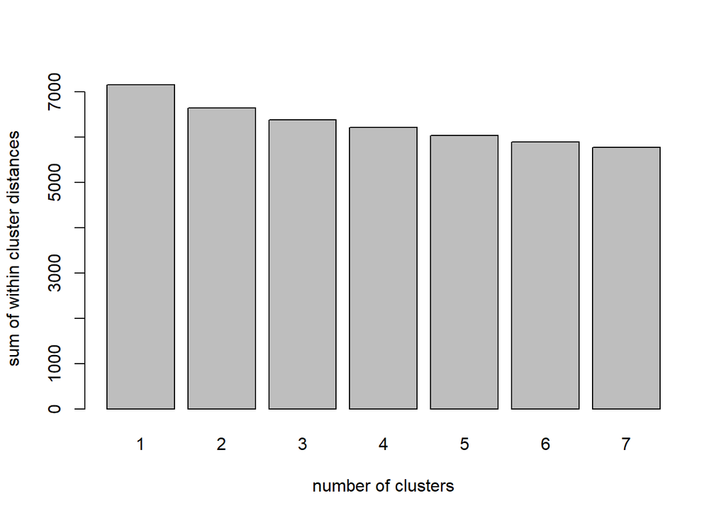

```r
plot(c_test)
```

It’s not super clear where the cutoff should be for this data. The distances drop off by about 170 for a few steps, then decline to a drop of 150 or so. I’m going to choose 4 as the number of clusters, but it’s fairly arbitrary. In general, a smaller number will result in a more tractable and stable solution.

# Running K-Means Clustering

I’m going to run the `cclust` command twice, specifying that it should use 4 clusters, and the manhattan distance metric, which is scale-invariant.

```r
# Cluster analysis
c1 <- cclust(sfo, k = 4, dist = "manhattan")
c1
```

```
## kcca object of family 'kmedians'
##
## call:
## cclust(x = sfo, k = 4, dist = "manhattan")
##
## cluster sizes:
##
##    1    2    3    4
## 1196 1007 1048  621
```

```r
## And again, see if results are stable
c2 <- cclust(sfo, k = 4, dist = "manhattan")
c2
```

```
## kcca object of family 'kmedians'
##
## call:
## cclust(x = sfo, k = 4, dist = "manhattan")
##
## cluster sizes:
##
##    1    2    3    4
##  720 1436 1067  649
```

Hmm, this gave us WAY different answers. Here’s why– the data aren’t strongly separated by various groups, so it depends where the starting points were.

To visualize this, we’ll use the `bootFlexclust` command, which will run the clustering algorithm on a subset of the data a certain number of times. This is called bootstrapping, and it shares many properties in common with cross-fold validation from last time. I’m going to do this for four different numbers of groups, from 2 through 5, then visualize the results.

```r
c1a <- bootFlexclust(x = sfo, k = c(2, 3, 4, 5), nboot = 50, verbose = TRUE)
```

```
## 10 20 30 40 50
```

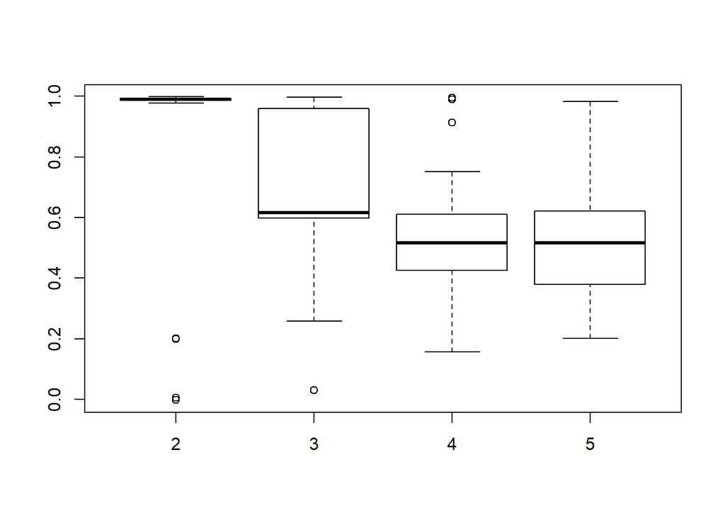

```r
plot(c1a)
```

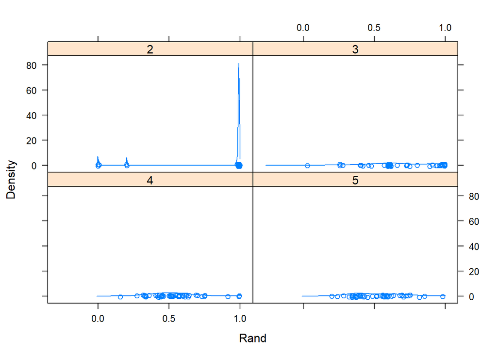

```r
densityplot(c1a)
```

With two groups, the cluster locations are pretty stable. At 3 they spread out. With 4 and five there appear to be some relatively steady points, but still it’s pretty spread out.

Okay, so that’s no good. What to do? Well, one thing to do is to apply this to a dataset with clearer groups. But, we’re going to plow on regardless. If we really want to find stable groupings, we need to find a way to converge on a stable classification into groups.

The `kmeanspp` (stands for k-means ++) command will repeat the kmeans clustering algorithm with different starting points until it converges on a stable solution. It basically repeats the process we saw above, but with the intention of getting to a stable solution.

```r
c2 <- kmeanspp(sfo, k = 4, start = "random", iter.max = 1000, nstart = 50)
table(c2$cluster)
```

```
##
##    1    2    3    4
##  960  851 1375  686
```

# Understanding cluster assignments

So now what? We need to figure out what these clusters mean by inspecting them as a function of the constituent variables.

```r
# Add predictions
sfo$cluster <- c2$cluster

# Examine relationship of cluster assignment to chars.
mycols <- c("Group 1", "Group 2", "Group 3", "Group 4")

# Frequency of travel
pt <- prop.table(table(sfo$cluster, sfo$sf.freq), margin = 1)
```

To create a nice table, we need to generate both row names and column names. We’ll also convert to percentages.

```r
rownames(pt) <- mycols
pt <- pt * 100
pt <- round(pt, 1)
```

The `kable` command will give us a nice looking table.

## Group membership by frequent traveler status

```r
kable(pt, row.names = TRUE, col.names = c("Not a frequent traveler", "Frequent traveler"))
```

|  | Not a frequent traveler | Frequent traveler |
| --- | --- | --- |
| Group 1 | 95.2 | 4.8 |
| Group 2 | 91.3 | 8.7 |
| Group 3 | 99.9 | 0.1 |
| Group 4 | 91.0 | 9.0 |

```r
pt <- prop.table(table(sfo$cluster, sfo$sf.mod_travel), margin = 1)

rownames(pt) <- mycols
pt <- pt * 100
pt <- round(pt, 1)
```

## Group membership by moderate traveler status

```r
kable(pt, row.names = TRUE, col.names = c("Not a moderate traveler", "Moderate traveler"))
```

|  | Not a moderate traveler | Moderate traveler |
| --- | --- | --- |
| Group 1 | 6.8 | 93.2 |
| Group 2 | 11.3 | 88.7 |
| Group 3 | 100.0 | 0.0 |
| Group 4 | 38.0 | 62.0 |

```r
# Age
prop.table(table(sfo$cluster, sfo$sf.age2544), margin = 1)
```

```
##
##              0          1
##   1 0.48437500 0.51562500
##   2 1.00000000 0.00000000
##   3 0.70763636 0.29236364
##   4 0.09037901 0.90962099
```

```r
prop.table(table(sfo$cluster, sfo$sf.age4564), margin = 1)
```

```
##
##               0           1
##   1 1.000000000 0.000000000
##   2 0.001175088 0.998824912
##   3 0.610909091 0.389090909
##   4 1.000000000 0.000000000
```

```r
# Reason for travel
pt <- prop.table(table(sfo$cluster, sfo$sf.business), margin = 1)

rownames(pt) <- mycols
pt <- pt * 100
pt <- round(pt, 1)
```

## Group membership by reason for travel

```r
kable(pt, row.names = TRUE, col.names = c("Not a business traveler", "Business traveler"))
```

|  | Not a business traveler | Business traveler |
| --- | --- | --- |
| Group 1 | 98.5 | 1.5 |
| Group 2 | 55.1 | 44.9 |
| Group 3 | 87.5 | 12.5 |
| Group 4 | 1.0 | 99.0 |

Let’s look at income:

```r
# Income
prop.table(table(sfo$cluster, sfo$sf.inc150p), margin = 1) %>% kable()
```

| 0 | 1 |
| --- | --- |
| 0.8677083 | 0.1322917 |
| 0.6274971 | 0.3725029 |
| 0.8727273 | 0.1272727 |
| 0.7361516 | 0.2638484 |

And now at whether they checked their bags

```r
# Checked bags?
prop.table(table(sfo$cluster, sfo$sf.bags), margin = 1) %>% kable()
```

[output not shown]

```r
# summarize groups

var.means <- colMeans(sfo)

## Drop the cluster means
var.means <- var.means[-(length(var.means))]
```